# Lab 3: Gesture Recognition using Convolutional Neural Networks

### Part (c) - 5 pt

Train your new network, including any hyperparameter tuning. Plot and submit the training curve of your best model only.

Note: Depending on how you are caching (saving) your AlexNet features, PyTorch might still be tracking updates to the **AlexNet weights**, which we are not tuning. One workaround is to convert your AlexNet feature tensor into a numpy array, and then back into a PyTorch tensor.

```python
def train_alex(net, batch_size=64, learning_rate=0.01, num_epochs=30):
    torch.manual_seed(1000)

    criterion = nn.CrossEntropyLoss()
    optimizer = optim.SGD(net.parameters(), lr=learning_rate, momentum=0.9)

    train_accuracy = np.zeros(num_epochs)
    val_accuracy = np.zeros(num_epochs)

    for epoch in range(num_epochs):  # loop over the dataset multiple times
        for inputs, labels in iter(train_feature_loader):
            inputs = inputs.cuda()
            labels = labels.cuda()
            # Zero the parameter gradients
            optimizer.zero_grad()
            # Forward pass, backward pass, and optimize
            outputs = net(inputs)
            loss = criterion(outputs, labels)
            loss.backward()
            optimizer.step()
            # Calculate the statistics

        train_accuracy[epoch] = accuracy(net, train_feature_loader)
        val_accuracy[epoch] = accuracy(net, val_feature_loader)
        print(("Epoch {}: Train accuracy: {} | Validation accuracy: {}")
              .format(
                    epoch + 1,
                    accuracy(net, train_feature_loader),
                    accuracy(net, val_feature_loader)))
        # Save the current model (checkpoint) to a file
        model_path = get_model_name(net.name, batch_size, learning_rate, epoch)
        torch.save(net.state_dict(), "./testing/"+model_path)
    print('Finished Training')

    return train_accuracy, val_accuracy, num_epochs
```

```
Epoch 1: Train accuracy: 0.40615615615615613 | Validation accuracy: 0.40765765765765766
Epoch 2: Train accuracy: 0.3258258258258258 | Validation accuracy: 0.32882882882882886
Epoch 3: Train accuracy: 0.6201201201201201 | Validation accuracy: 0.581081081081081
Epoch 4: Train accuracy: 0.6351351351351351 | Validation accuracy: 0.6036036036036037
Epoch 5: Train accuracy: 0.8093093093093093 | Validation accuracy: 0.7837837837837838
Epoch 6: Train accuracy: 0.8701201201201201 | Validation accuracy: 0.8400900900900901
Epoch 7: Train accuracy: 0.9076576576576577 | Validation accuracy: 0.8986486486486487
Epoch 8: Train accuracy: 0.9136636636636637 | Validation accuracy: 0.8806306306306306
Epoch 9: Train accuracy: 0.9324324324324325 | Validation accuracy: 0.9054054054054054
Epoch 10: Train accuracy: 0.93993993993994 | Validation accuracy: 0.9234234234234234
Epoch 11: Train accuracy: 0.9429429429429429 | Validation accuracy: 0.9211711711711712
Epoch 12: Train accuracy: 0.9496996996996997 | Validation accuracy: 0.9279279279279279
Epoch 13: Train accuracy: 0.9527027027027027 | Validation accuracy: 0.9279279279279279
Epoch 14: Train accuracy: 0.9474474474474475 | Validation accuracy: 0.9166666666666666
Epoch 15: Train accuracy: 0.9527027027027027 | Validation accuracy: 0.9324324324324325
Epoch 16: Train accuracy: 0.9632132132132132 | Validation accuracy: 0.9301801801801802
Epoch 17: Train accuracy: 0.9654654654654654 | Validation accuracy: 0.9391891891891891
Epoch 18: Train accuracy: 0.9654654654654654 | Validation accuracy: 0.9414414414414415
Epoch 19: Train accuracy: 0.9632132132132132 | Validation accuracy: 0.9256756756756757
Epoch 20: Train accuracy: 0.9677177177177178 | Validation accuracy: 0.9369369369369369
Epoch 21: Train accuracy: 0.9692192192192193 | Validation accuracy: 0.9346846846846847
Epoch 22: Train accuracy: 0.9692192192192193 | Validation accuracy: 0.9369369369369369
Epoch 23: Train accuracy: 0.96996996996997 | Validation accuracy: 0.9301801801801802
Epoch 24: Train accuracy: 0.9714714714714715 | Validation accuracy: 0.9324324324324325
Epoch 25: Train accuracy: 0.9714714714714715 | Validation accuracy: 0.9436936936936937
Epoch 26: Train accuracy: 0.9722222222222222 | Validation accuracy: 0.9414414414414415
Epoch 27: Train accuracy: 0.972972972972973 | Validation accuracy: 0.9414414414414415
Epoch 28: Train accuracy: 0.972972972972973 | Validation accuracy: 0.9346846846846847
Epoch 29: Train accuracy: 0.972972972972973 | Validation accuracy: 0.9459459459459459
Epoch 30: Train accuracy: 0.9737237237237237 | Validation accuracy: 0.9414414414414415
Finished Training
```

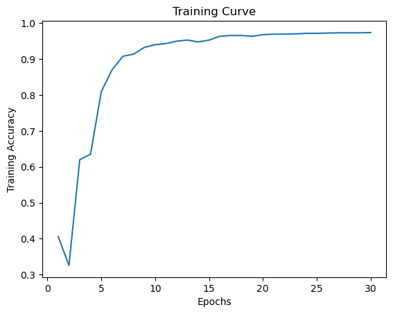

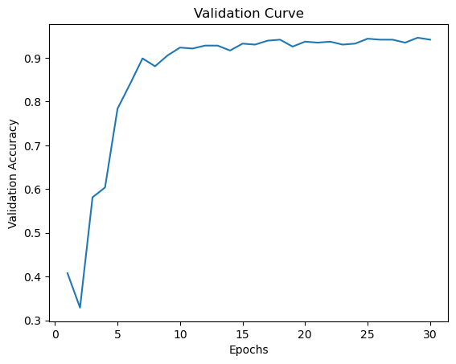

```python
ANN = AlexNet()
ANN.cuda()

training_accuracy, validation_accuracy, num_epoches = train_alex(ANN)

plt.plot(np.arange(1, num_epoches + 1), training_accuracy)
plt.title("Training Curve")
plt.xlabel("Epochs")
plt.ylabel("Training Accuracy")
plt.show()

plt.plot(np.arange(1, num_epoches + 1), validation_accuracy)
plt.title("Validation Curve")
plt.xlabel("Epochs")
plt.ylabel("Validation Accuracy")
```

### Part (d) - 2 pt

Report the test accuracy of your best model. How does the test accuracy compare to Part 3(d) without transfer learning?

```python
AN = AlexNet()
AN.cuda()
model_path = get_model_name(AN.name, batch_size=64, learning_rate=0.01, epoch=30-1)
state = torch.load("./testing/" + model_path)
AN.load_state_dict(state)

accuracy(AN, test_feature_loader)
```

```
0.9300225733634312
```

### 5. Additional Testing [5 pt]

As a final step in testing we will be revisiting the sample images that you had collected and submitted at the start of this lab. These sample images should be untouched and will be used to demonstrate how well your model works at identifying your hand guestures.

Using the best transfer learning model developed in Part 4. Report the test accuracy on your sample images and how it compares to the test accuracy obtained in Part 4(d)? How well did your model do for the different hand guestures? Provide an explanation for why you think your model performed the way it did?

```python
accuracy(AN, test_loader)
```

[output not shown]